# Question

By [completing the square](https://en.wikipedia.org/wiki/Completing_the_square), find the positive solution to the given equation:

$$x^2+18x~=~88$$

# Solution

The given equation:

$$x^2+18x~=~88$$

We can visualize this as the areas of a small square and two rectangles. Notice we divide the linear coefficient by 2 to find one dimension of the rectangles.

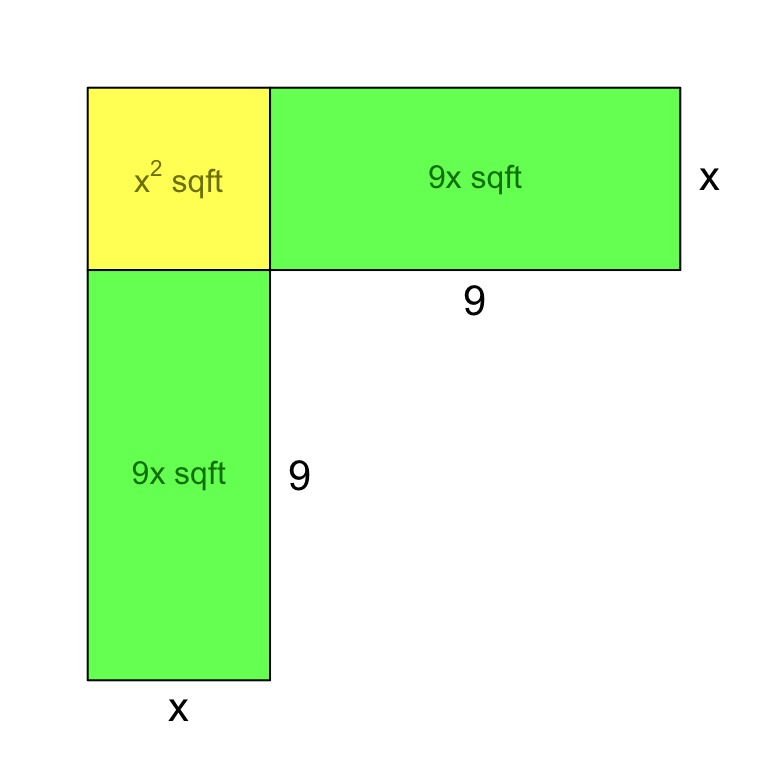

$$x^2+9x+9x~=~88$$

There is a fun way to solve this. We will “complete the square”. In this situation, the means we can imagine adding some extra area to the picture to make a large square. In this case, we need to add a square with edge lengths of 9, adding 81 square feet to the area.

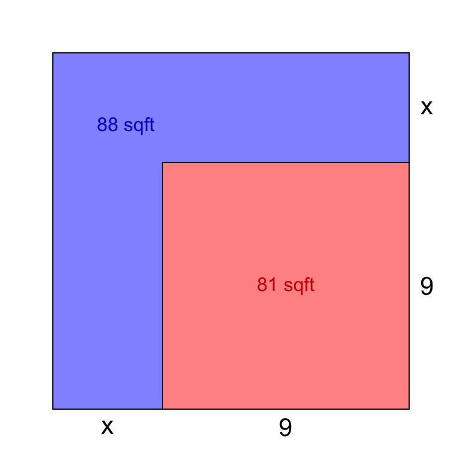

$$x^2+18x+81~=~88+81$$

$$x^2+18x+81~=~169$$

But, notice, if you look at the last picture, we have another way to represent the total area. The newly formed large square has side lengths of $x+9$. So we can represent the total area of the large square as $(x+9)^2$.

$$(x+9)^2~=~169$$

$$x+9~=~\pm 13$$

And, lastly, subtract 9 from both sides of the equation. We only care about the positive solution.

$$x~=~13-9$$

$$x~=~4$$

# Meta-information

extype: num exsolution: 4 exname: complete_the_square_D